# Report_mushroom

```
Name：李品慈                    Student ID: 0816039
```

## Data input

```python
# importing panda library
import pandas as pd
import numpy as np

# ignore warnings
import warnings
warnings.filterwarnings('ignore')

# readinag given csv file
# and creating dataframe
mushroom = pd.read_csv("agaricus-lepiota.data")

# adding column headings
mushroom.columns = ['class',
                      'cap-shape', 'cap-surface', 'cap-color', 'bruises', 'odor',
                      'gill-attachment', 'gill-spacing', 'gill-size', 'gill-color',
                      'stalk-shape', 'stalk-root', 'stalk-surface-above-ring', 'stalk-surface-below-ring',
                      'stalk-color-above-ring', 'stalk-color-below-ring',
                      'veil-type', 'veil-color', 'ring-number', 'ring-type', 'spore-print-color',
                      'population', 'habitat']

# storing this dataframe in a csv file
mushroom.to_csv('agaricus-lepiota.csv', index = None)

# read from csv file
mushroom = pd.read_csv("agaricus-lepiota.csv")
```

```python
mushroom.head()
```

|  | class | cap-shape | cap-surface | cap-color | bruises | odor | gill-attachment | gill-spacing | gill-size | gill-color | stalk-shape | stalk-root | stalk-surface-above-ring | stalk-surface-below-ring | stalk-color-above-ring | stalk-color-below-ring | veil-type | veil-color | ring-number | ring-type | spore-print-color | population | habitat |
| --- | --- | --- | --- | --- | --- | --- | --- | --- | --- | --- | --- | --- | --- | --- | --- | --- | --- | --- | --- | --- | --- | --- | --- |
| 0 | e | x | s | y | t | a | f | c | b | k | e | c | s | s | w | w | p | w | o | p | n | n | g |
| 1 | e | b | s | w | t | l | f | c | b | n | e | c | s | s | w | w | p | w | o | p | n | n | m |
| 2 | p | x | y | w | t | p | f | c | n | n | e | e | s | s | w | w | p | w | o | p | k | s | u |
| 3 | e | x | s | g | f | n | f | w | b | k | t | e | s | s | w | w | p | w | o | e | n | a | g |
| 4 | e | x | y | y | t | a | f | c | b | n | e | c | s | s | w | w | p | w | o | p | k | n | g |

## Data Visualization

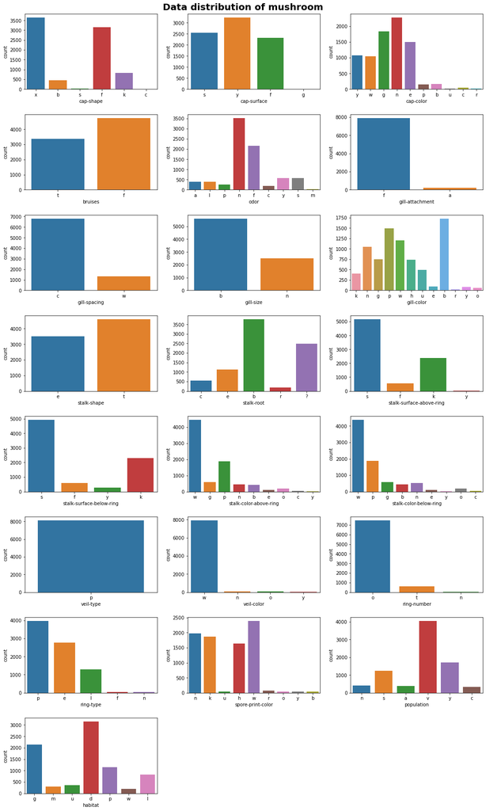

```python
# import lib
import matplotlib.pyplot as plt
import seaborn as sns


mushroom_features = ['cap-shape', 'cap-surface', 'cap-color', 'bruises', 'odor',
                     'gill-attachment', 'gill-spacing', 'gill-size', 'gill-color',
                     'stalk-shape', 'stalk-root', 'stalk-surface-above-ring', 'stalk-surface-below-ring',
                     'stalk-color-above-ring', 'stalk-color-below-ring',
                     'veil-type', 'veil-color', 'ring-number', 'ring-type', 'spore-print-color',
                     'population', 'habitat']


# draw subplots
fig, axes = plt.subplots(8, 3)
fig.set_figheight(25)
fig.set_figwidth(15)
fig.suptitle('Data distribution of mushroom', fontweight="bold", size=20)

count = 0

for feature in mushroom_features:
    sns.countplot(ax=axes[int(count/3), count%3], x = mushroom[feature])
    count+=1
fig.delaxes(axes[7][1])
fig.delaxes(axes[7][2])
fig.tight_layout(pad=2)
```

### - Split data based on their labels (targets) and show the data distribution

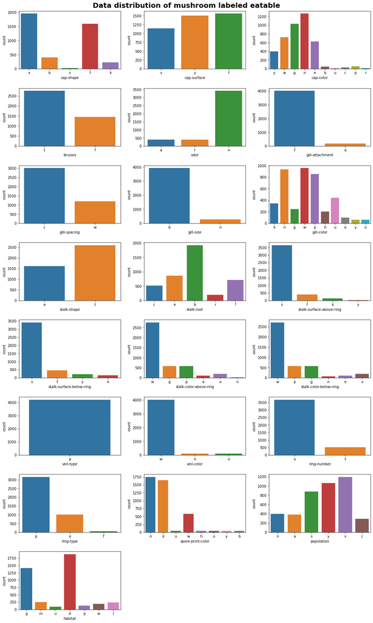

```python
# mushroon_label = ['e', 'p']
label_e = mushroom[mushroom["class"] == 'e']

fig, axes = plt.subplots(8, 3)
fig.set_figheight(25)
fig.set_figwidth(15)
fig.suptitle('Data distribution of mushroom labeled eatable', fontweight="bold", size=20)

count = 0

for feature in mushroom_features:
    sns.countplot(ax=axes[int(count/3), count%3], x = label_e[feature])
    count+=1
fig.delaxes(axes[7][1])
fig.delaxes(axes[7][2])
plt.tight_layout(pad=2)
```

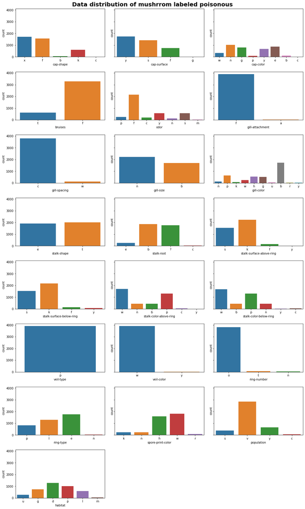

```python
label_p = mushroom[mushroom["class"] == 'p']

fig, axes = plt.subplots(8, 3, sharey=True)
fig.set_figheight(25)
fig.set_figwidth(15)
fig.suptitle('Data distribution of mushrrom labeled poisonous', fontweight="bold", size=20)

count = 0

for feature in mushroom_features:
    sns.countplot(ax=axes[int(count/3), count%3], x = label_p[feature])
    count+=1
fig.delaxes(axes[7][1])
fig.delaxes(axes[7][2])
plt.tight_layout(pad=2)
```

## Data preprocessing

```python
# Drop features with any missing value
mushroom = mushroom.replace('?', np.nan)
mushroom = mushroom.dropna(axis = 1)

# Transform data format and shape so your model can process them. #

# Shuffle the data
mushroom = mushroom.sample(frac=1)

# Any other transformation boosts the final performance
################## Maybe do something here ########################


########################### END ##########################

mushroom.head()
```

|  | class | cap-shape | cap-surface | cap-color | bruises | odor | gill-attachment | gill-spacing | gill-size | gill-color | stalk-shape | stalk-surface-above-ring | stalk-surface-below-ring | stalk-color-above-ring | stalk-color-below-ring | veil-type | veil-color | ring-number | ring-type | spore-print-color | population | habitat |
| --- | --- | --- | --- | --- | --- | --- | --- | --- | --- | --- | --- | --- | --- | --- | --- | --- | --- | --- | --- | --- | --- | --- |
| 5829 | p | x | s | w | t | f | f | c | b | w | t | s | f | w | w | p | w | o | p | h | s | g |
| 6313 | p | x | s | n | f | f | f | c | n | b | t | k | s | w | p | p | w | o | e | w | v | d |
| 7740 | e | x | s | n | f | n | a | c | b | n | e | s | s | o | o | p | o | o | p | y | c | l |
| 3619 | e | f | f | e | t | n | f | c | b | p | t | s | s | w | w | p | w | o | p | n | y | d |
| 7906 | e | b | f | w | f | n | f | w | b | w | e | s | s | w | w | p | w | t | p | w | s | g |

## Train-Test-Split & Model construction: holdout validation

```python
from sklearn.model_selection import train_test_split

mushroom_data = mushroom.drop('class', axis = 1)
mushroom_data = pd.get_dummies(mushroom_data)
pd.DataFrame(mushroom_data)
mushroom_class = mushroom['class']


X_train,X_test,y_train,y_test=train_test_split(mushroom_data,mushroom_class,test_size=0.3)
```

### - Results: with laplace smoothing

```python
from sklearn.naive_bayes import MultinomialNB

mushroom_model=MultinomialNB()
mushroom_model.fit(X_train,y_train)
```

```
MultinomialNB()
```

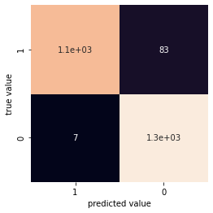

```
+------------+----------+-------------+
|   accuracy |   recall |   precision |
+============+==========+=============+
|   0.963069 | 0.929482 |    0.993642 |
+------------+----------+-------------+
```

```python
# import lib
from sklearn.metrics import confusion_matrix
from sklearn.metrics.classification import accuracy_score
from sklearn.metrics.classification import recall_score
from sklearn.metrics.classification import precision_score
from tabulate import tabulate


y_predict = mushroom_model.predict(X_test)

# results: confusion matrix
mat1 = confusion_matrix(y_test, y_predict)
sns.heatmap(mat1,square= True, annot=True, cbar= False)
plt.gca().invert_xaxis()
plt.gca().invert_yaxis()
plt.xlabel("predicted value")
plt.ylabel("true value")
plt.show()

# results: accuracy
accuracy1 = accuracy_score(y_test, y_predict)

# results: sensitivity(recall)
recall1 = recall_score(y_test, y_predict, pos_label="p")

# results: precision
precision1 = precision_score(y_test, y_predict, pos_label="p")

# draw table with accuracy, recall, precision
data = [[accuracy1, recall1, precision1]]

headers = ["accuracy", "recall", "precision"]

print(tabulate(data, headers= headers, tablefmt= "grid"))
```

### - Results: without laplace smoothing

```python
mushroom_model2=MultinomialNB(alpha = 0)
mushroom_model2.fit(X_train,y_train)
```

```
MultinomialNB(alpha=0)
```

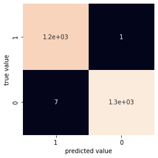

```
+------------+----------+-------------+
|   accuracy |   recall |   precision |
+============+==========+=============+
|   0.996717 |  0.99915 |    0.994083 |
+------------+----------+-------------+
```

```python
y_predict = mushroom_model2.predict(X_test)

# results: confusion matrix
mat2 = confusion_matrix(y_test, y_predict)
sns.heatmap(mat2,square= True, annot=True, cbar= False)
plt.gca().invert_xaxis()
plt.gca().invert_yaxis()
plt.xlabel("predicted value")
plt.ylabel("true value")
plt.show()

# results: accuracy
accuracy2 = accuracy_score(y_test, y_predict)

# results: sensitivity(recall)
recall2 = recall_score(y_test, y_predict, pos_label="p")

# results: precision
precision2 = precision_score(y_test, y_predict, pos_label="p")

# draw table with accuracy, recall, precision
data = [[accuracy2, recall2, precision2]]

headers = ["accuracy", "recall", "precision"]

print(tabulate(data, headers= headers, tablefmt= "grid"))
```

## Train-Test-Split & Model construction: K-fold cross-validation

```python
mushroom_model3=MultinomialNB()
mushroom_model4=MultinomialNB(alpha = 0)
```

```python
import statistics
from sklearn.model_selection import StratifiedKFold
folds = StratifiedKFold(n_splits=3)

m1_accscores = []
m1_recscores = []
m1_prescores = []
m2_accscores = []
m2_recscores = []
m2_prescores = []

cm1_holder = []
cm2_holder = []

for train_index, test_index in folds.split(mushroom_data,mushroom_class):
    X_train, X_test, y_train, y_test = mushroom_data.iloc[train_index], mushroom_data.iloc[test_index], \
                                       mushroom_class.iloc[train_index], mushroom_class.iloc[test_index]
    # test mushroom_model3
    mushroom_model3.fit(X_train, y_train)
    y_predict = mushroom_model3.predict(X_test)
    cm1_holder.append(confusion_matrix(y_test, y_predict))
    m1_accscores.append(accuracy_score(y_test, y_predict))
    m1_recscores.append(recall_score(y_test, y_predict, pos_label="p"))
    m1_prescores.append(recall_score(y_test, y_predict, pos_label="p"))

    # test mushroom_model4
    mushroom_model4.fit(X_train, y_train)
    y_predict = mushroom_model4.predict(X_test)
    cm2_holder.append(confusion_matrix(y_test, y_predict))
    m2_accscores.append(accuracy_score(y_test, y_predict))
    m2_recscores.append(recall_score(y_test, y_predict, pos_label="p"))
    m2_prescores.append(recall_score(y_test, y_predict, pos_label="p"))
```

### - Results: with laplace smoothing

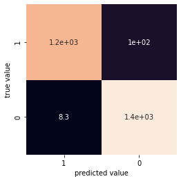

```
+------------+----------+-------------+
|   accuracy |   recall |   precision |
+============+==========+=============+
|   0.959005 | 0.921328 |    0.921328 |
+------------+----------+-------------+
```

```python
# results: confusion matrix
mat3 = sum(cm1_holder)/3
sns.heatmap(mat3,square= True, annot=True, cbar= False)
plt.gca().invert_xaxis()
plt.gca().invert_yaxis()
plt.xlabel("predicted value")
plt.ylabel("true value")
plt.show()

# results: accuracy
accuracy3 = statistics.mean(m1_accscores)

# results: sensitivity(recall)
recall3 = statistics.mean(m1_recscores)

# results: precision
precision3 = statistics.mean(m1_prescores)

# draw table with accuracy, recall, precision
data = [[accuracy3, recall3, precision3]]

headers = ["accuracy", "recall", "precision"]

print(tabulate(data, headers= headers, tablefmt= "grid"))
```

### - Results: without laplace smoothing

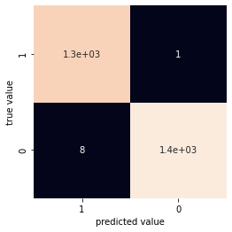

```
+------------+----------+-------------+
|   accuracy |   recall |   precision |
+============+==========+=============+
|   0.996676 | 0.999234 |    0.999234 |
+------------+----------+-------------+
```

```python
# results: confusion matrix
mat4 = sum(cm2_holder)/3
sns.heatmap(mat4,square= True, annot=True, cbar= False)
plt.gca().invert_xaxis()
plt.gca().invert_yaxis()
plt.xlabel("predicted value")
plt.ylabel("true value")
plt.show()

# results: accuracy
accuracy4 = statistics.mean(m2_accscores)

# results: sensitivity(recall)
recall4 = statistics.mean(m2_recscores)

# results: precision
precision4 = statistics.mean(m2_prescores)

# draw table with accuracy, recall, precision
data = [[accuracy4, recall4, precision4]]

headers = ["accuracy", "recall", "precision"]

print(tabulate(data, headers= headers, tablefmt= "grid"))
```

## Comparison & Conclusion

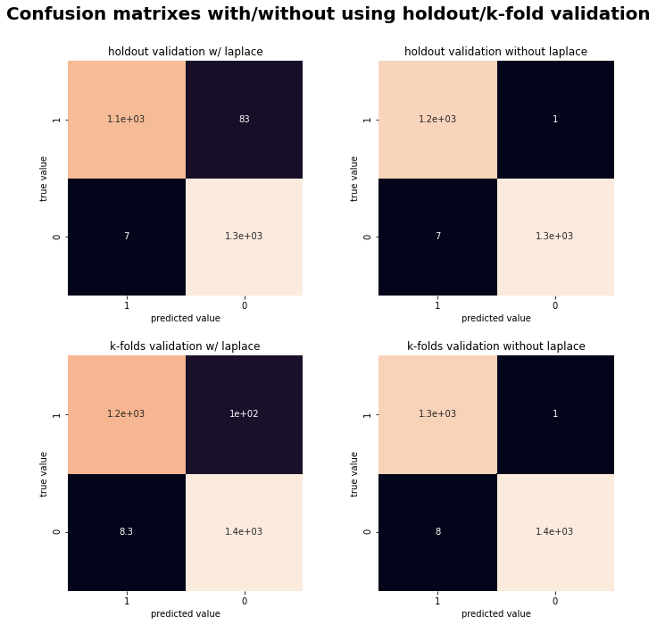

```python
# Build subplot
fig, axes = plt.subplots(2, 2)
fig.set_figheight(10)
fig.set_figwidth(10)
fig.suptitle('Confusion matrixes with/without using holdout/k-fold validation', fontweight="bold", size=20)

sns.heatmap(mat1,square= True, annot=True, cbar= False, ax = axes[0][0])
axes[0, 0].set_title('holdout validation w/ laplace')
axes[0, 0].invert_xaxis()
axes[0, 0].invert_yaxis()


sns.heatmap(mat2,square= True, annot=True, cbar= False, ax = axes[0][1])
axes[0, 1].set_title('holdout validation without laplace')
axes[0, 1].invert_xaxis()
axes[0, 1].invert_yaxis()

sns.heatmap(mat3,square= True, annot=True, cbar= False, ax = axes[1][0])
axes[1, 0].set_title('k-folds validation w/ laplace')
axes[1, 0].invert_xaxis()
axes[1, 0].invert_yaxis()

sns.heatmap(mat4,square= True, annot=True, cbar= False, ax = axes[1][1])
axes[1, 1].set_title('k-folds validation without laplace')
axes[1, 1].invert_xaxis()
axes[1, 1].invert_yaxis()

# name x and y axis
plt.setp(axes[:, :], xlabel='predicted value')
plt.setp(axes[:, :], ylabel='true value')

# print out the subplot
plt.tight_layout(pad=2)
```

從上圖我們可以得知：

```python
# draw table with accuracy, recall, precision
data = [["holdout & laplace", accuracy1, recall1, precision1],
        ["holdout without laplace", accuracy2, recall2, precision2],
        ["k-folds & laplace", accuracy3, recall3, precision3],
        ["k-folds without laplace", accuracy4, recall4, precision4]]

headers = ["", "accuracy", "recall", "precision"]

print(tabulate(data, headers= headers, tablefmt= "fancy_grid"))
```

```
╒═════════════════════════╤════════════╤══════════╤═════════════╕
│                         │   accuracy │   recall │   precision │
╞═════════════════════════╪════════════╪══════════╪═════════════╡
│ holdout & laplace       │   0.963069 │ 0.929482 │    0.993642 │
├─────────────────────────┼────────────┼──────────┼─────────────┤
│ holdout without laplace │   0.996717 │ 0.99915  │    0.994083 │
├─────────────────────────┼────────────┼──────────┼─────────────┤
│ k-folds & laplace       │   0.959005 │ 0.921328 │    0.921328 │
├─────────────────────────┼────────────┼──────────┼─────────────┤
│ k-folds without laplace │   0.996676 │ 0.999234 │    0.999234 │
╘═════════════════════════╧════════════╧══════════╧═════════════╛
```

從上圖我們可以得知各項validation和lapace smoothing之後的performance：

從表格中可以看出，k-folds without laplace和holdout without laplace的表現非常的好，兩者三項的performance都有99%的準確率。

## Questions

- Show 𝑃(𝑋𝑠𝑡𝑎𝑙𝑘−𝑐𝑜𝑙𝑜𝑟−𝑏𝑒𝑙𝑜𝑤−𝑟𝑖𝑛𝑔|𝑌=𝑒) with and without Laplace smoothing by bar charts

```python
'''
# mushroom_model.classes_ # output: array(['e', 'p'], dtype='<U1')
# mushroom_model.n_features_ # output : 112

list(mushroom_data.columns)
output:
 ...
 68: 'stalk-color-below-ring_b'
 69: 'stalk-color-below-ring_c'
 70: 'stalk-color-below-ring_e'
 71: 'stalk-color-below-ring_g'
 72: 'stalk-color-below-ring_n'
 73: 'stalk-color-below-ring_o'
 74: 'stalk-color-below-ring_p'
 75: 'stalk-color-below-ring_w'
 76: 'stalk-color-below-ring_y'
 ...
'''

# calculate the condition probability
count = 68
holdout_with_log_prob = []
holdout_without_log_prob = []
kfolds_with_log_prob = []
kfolds_without_log_prob = []
for color in ['b','c','e','g','n','o','p','w','y']:
    holdout_with_log_prob.append(mushroom_model.feature_log_prob_[0][count])
    holdout_without_log_prob.append(mushroom_model2.feature_log_prob_[0][count])
    kfolds_with_log_prob.append(mushroom_model3.feature_log_prob_[0][count])
    kfolds_without_log_prob.append(mushroom_model4.feature_log_prob_[0][count])

    count+=1


# remove the log part
holdout_with_log_prob = np.array(holdout_with_log_prob)
holdout_without_log_prob = np.array(holdout_without_log_prob)
kfolds_with_log_prob = np.array(kfolds_with_log_prob)
kfolds_without_log_prob = np.array(kfolds_without_log_prob)

holdout_with_log_prob = np.exp(1)** holdout_with_log_prob
holdout_without_log_prob = np.exp(1)** holdout_without_log_prob
kfolds_with_log_prob = np.exp(1)** kfolds_with_log_prob
kfolds_without_log_prob = np.exp(1)** kfolds_without_log_prob
```

```python
# build data frame
data = {'color': ['b', 'b', 'b', 'b', 'c', 'c', 'c', 'c', 'e', 'e', 'e', 'e', 'g', 'g', 'g', 'g', 'n', 'n', 'n', 'n', 'o', 'o', 'o', 'o', 'p', 'p', 'p', 'p', 'w', 'w', 'w', 'w', 'y', 'y', 'y', 'y'],
         'validation and laplace': ['holdout with laplace', 'holdout without laplace', 'kfolds with laplace', 'kfolds without laplace', 'holdout with laplace', 'holdout without laplace', 'kfolds with laplace', 'kfolds without laplace', 'holdout with laplace', 'holdout without laplace', 'kfolds with laplace', 'kfolds without laplace', 'holdout with laplace', 'holdout without laplace', 'kfolds with laplace', 'kfolds without laplace', 'holdout with laplace', 'holdout without laplace', 'kfolds with laplace', 'kfolds without laplace', 'holdout with laplace', 'holdout without laplace', 'kfolds with laplace', 'kfolds without laplace', 'holdout with laplace', 'holdout without laplace', 'kfolds with laplace', 'kfolds without laplace', 'holdout with laplace', 'holdout without laplace', 'kfolds with laplace', 'kfolds without laplace', 'holdout with laplace', 'holdout without laplace', 'kfolds with laplace', 'kfolds without laplace'],
         'value': [holdout_with_log_prob[0], holdout_without_log_prob[0], kfolds_with_log_prob[0], kfolds_without_log_prob[0], holdout_with_log_prob[1], holdout_without_log_prob[1], kfolds_with_log_prob[1], kfolds_without_log_prob[1], holdout_with_log_prob[2], holdout_without_log_prob[2], kfolds_with_log_prob[2], kfolds_without_log_prob[2], holdout_with_log_prob[3], holdout_without_log_prob[3], kfolds_with_log_prob[3], kfolds_without_log_prob[3], holdout_with_log_prob[4], holdout_without_log_prob[4], kfolds_with_log_prob[4], kfolds_without_log_prob[4], holdout_with_log_prob[5], holdout_without_log_prob[5], kfolds_with_log_prob[5], kfolds_without_log_prob[5], holdout_with_log_prob[6], holdout_without_log_prob[6], kfolds_with_log_prob[6], kfolds_without_log_prob[6], holdout_with_log_prob[7], holdout_without_log_prob[7], kfolds_with_log_prob[7], kfolds_without_log_prob[7], holdout_with_log_prob[8], holdout_without_log_prob[8], kfolds_with_log_prob[8], kfolds_without_log_prob[8]]
        }
data = pd.DataFrame(data2)
```

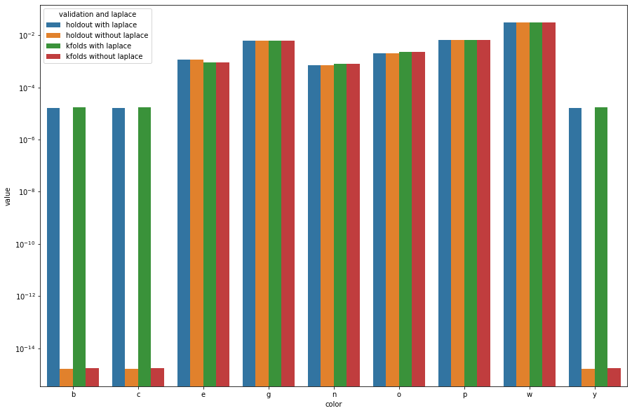

```python
# print bat chart
fig, axes = plt.subplots(1, 1)
fig.set_figheight(10)
fig.set_figwidth(15)
g = sns.barplot(x = 'color',y = 'value' , data = data, hue = 'validation and laplace')
g.set_yscale("log")
plt.show()
```